# EDLD 651 Draft Data Preparation Script

Author

Febe Lin, Ramtin Ranjpour, & James Phillips

# Load the data set

```r
student_social <- import(here("data", "final_students_social_media.csv"))

head(student_social)
```

```
  Student_ID Age Gender Academic_Level    Country Affects_Academic_Performance
1          1  19 Female  Undergraduate Bangladesh                          Yes
2          2  22   Male       Graduate      India                           No
3          3  20 Female  Undergraduate        USA                          Yes
4          4  18   Male    High School         UK                           No
5          5  21   Male       Graduate     Canada                          Yes
6          6  19 Female  Undergraduate  Australia                          Yes
  Sleep_Hours_Per_Night Mental_Health_Score Relationship_Status
1                   6.5                   6     In Relationship
2                   7.5                   8              Single
3                   5.0                   5         Complicated
4                   7.0                   7              Single
5                   6.0                   6     In Relationship
6                   4.5                   4         Complicated
  Conflicts_Over_Social_Media Addicted_Score Instagram Twitter TikTok YouTube
1                           3              8       5.2      NA     NA      NA
2                           0              3        NA     2.1     NA      NA
3                           4              9        NA      NA      6      NA
4                           1              4        NA      NA     NA       3
5                           2              7        NA      NA     NA      NA
6                           5              9       7.2      NA     NA      NA
  Facebook LinkedIn Snapchat LINE KakaoTalk VKontakte WhatsApp WeChat
1       NA       NA       NA   NA        NA        NA       NA     NA
2       NA       NA       NA   NA        NA        NA       NA     NA
3       NA       NA       NA   NA        NA        NA       NA     NA
4       NA       NA       NA   NA        NA        NA       NA     NA
5      4.5       NA       NA   NA        NA        NA       NA     NA
6       NA       NA       NA   NA        NA        NA       NA     NA
```

The data is not tidy because the column names (Instagram, TikTok, etc.) are actually values of a variable, not the names of variables themselves.

# Clean the data

```r
tidy_data <- student_social |>
  pivot_longer(cols = Instagram : last_col(),
               names_to ="Most_Used_Platform",
               values_to = "Avg_Daily_Usage_Hours",
               values_drop_na = TRUE)

head(tidy_data)
```

```
# A tibble: 6 × 13
  Student_ID   Age Gender Academic_Level Country    Affects_Academic_Performance
       <int> <int> <chr>  <chr>          <chr>      <chr>
1          1    19 Female Undergraduate  Bangladesh Yes
2          2    22 Male   Graduate       India      No
3          3    20 Female Undergraduate  USA        Yes
4          4    18 Male   High School    UK         No
5          5    21 Male   Graduate       Canada     Yes
6          6    19 Female Undergraduate  Australia  Yes
# ℹ 7 more variables: Sleep_Hours_Per_Night <dbl>, Mental_Health_Score <int>,
#   Relationship_Status <chr>, Conflicts_Over_Social_Media <int>,
#   Addicted_Score <int>, Most_Used_Platform <chr>, Avg_Daily_Usage_Hours <dbl>
```

```r
export(tidy_data, here("data", "tidy_data.csv"))
```

# Explore our questions

## RQ1-RQ2, H1-H3

*RQ*<sub>1</sub>: Does sleep deprivation mediate the negative relationship between daily screen time and mental health scores?

*H*<sub>1</sub>: Screen time negatively predicts sleep time, which in turn negatively impacts mental health.

```r
# test mental ~ screen time
model_test <-lm(Mental_Health_Score~Avg_Daily_Usage_Hours,data = tidy_data)
summary(model_test)
```

```
Call:
lm(formula = Mental_Health_Score ~ Avg_Daily_Usage_Hours, data = tidy_data)

Residuals:
     Min       1Q   Median       3Q      Max
-2.01454 -0.39532  0.07025  0.46387  1.68947

Coefficients:
                      Estimate Std. Error t value Pr(>|t|)
(Intercept)            9.68976    0.10073   96.20   <2e-16 ***
Avg_Daily_Usage_Hours -0.70401    0.01984  -35.48   <2e-16 ***
---
Signif. codes:  0 '***' 0.001 '**' 0.01 '*' 0.05 '.' 0.1 ' ' 1

Residual standard error: 0.6619 on 703 degrees of freedom
Multiple R-squared:  0.6417,    Adjusted R-squared:  0.6412
F-statistic:  1259 on 1 and 703 DF,  p-value: < 2.2e-16
```

```r
# test sleep hours ~ screen time
model_path_a <- lm(Sleep_Hours_Per_Night ~ Avg_Daily_Usage_Hours, data = tidy_data)
summary(model_path_a)
```

```
Call:
lm(formula = Sleep_Hours_Per_Night ~ Avg_Daily_Usage_Hours, data = tidy_data)

Residuals:
    Min      1Q  Median      3Q     Max
-3.0656 -0.2401  0.2344  0.4344  1.5635

Coefficients:
                      Estimate Std. Error t value Pr(>|t|)
(Intercept)            10.3539     0.1051   98.54   <2e-16 ***
Avg_Daily_Usage_Hours  -0.7085     0.0207  -34.23   <2e-16 ***
---
Signif. codes:  0 '***' 0.001 '**' 0.01 '*' 0.05 '.' 0.1 ' ' 1

Residual standard error: 0.6905 on 703 degrees of freedom
Multiple R-squared:  0.625, Adjusted R-squared:  0.6245
F-statistic:  1172 on 1 and 703 DF,  p-value: < 2.2e-16
```

```r
# test mental ~ screen time + sleep hours
model_full <- lm(Mental_Health_Score ~ Avg_Daily_Usage_Hours + Sleep_Hours_Per_Night, data = tidy_data)
summary(model_full)
```

```
Call:
lm(formula = Mental_Health_Score ~ Avg_Daily_Usage_Hours + Sleep_Hours_Per_Night,
    data = tidy_data)

Residuals:
     Min       1Q   Median       3Q      Max
-2.09955 -0.39062  0.09584  0.43282  1.64159

Coefficients:
                      Estimate Std. Error t value Pr(>|t|)
(Intercept)            7.68230    0.37991  20.221  < 2e-16 ***
Avg_Daily_Usage_Hours -0.56664    0.03175 -17.845  < 2e-16 ***
Sleep_Hours_Per_Night  0.19388    0.03543   5.472  6.2e-08 ***
---
Signif. codes:  0 '***' 0.001 '**' 0.01 '*' 0.05 '.' 0.1 ' ' 1

Residual standard error: 0.6487 on 702 degrees of freedom
Multiple R-squared:  0.6564,    Adjusted R-squared:  0.6554
F-statistic: 670.4 on 2 and 702 DF,  p-value: < 2.2e-16
```

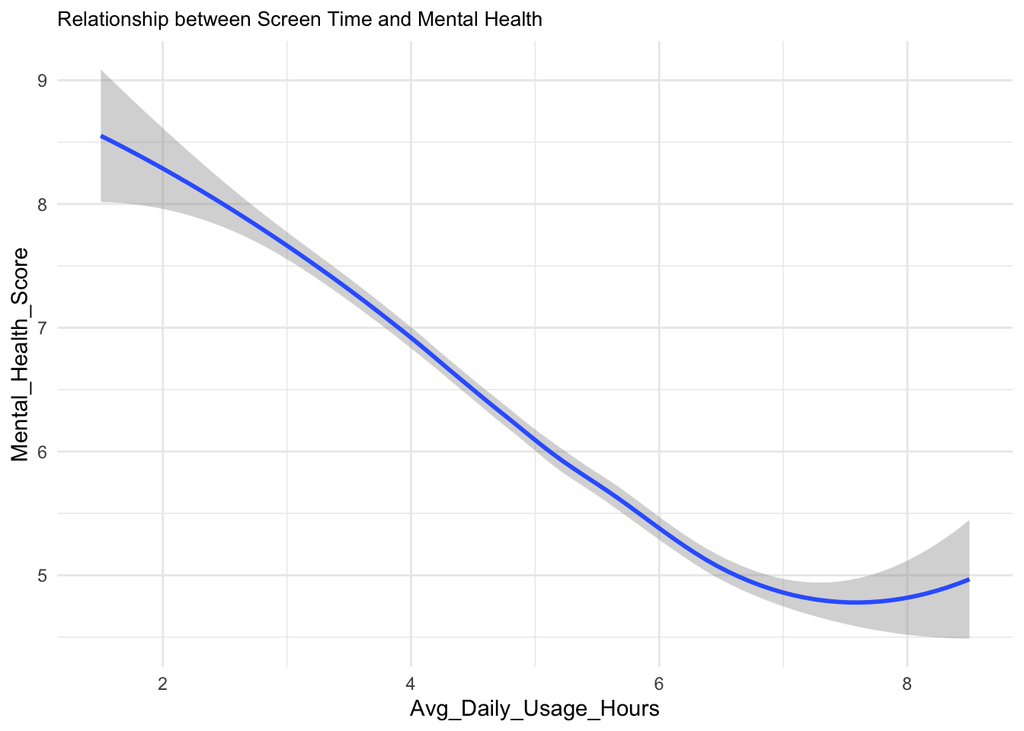

```r
#plot
ggplot(tidy_data,
       aes(x= Avg_Daily_Usage_Hours, y= Mental_Health_Score))+
  geom_smooth(model= "lm", se= TRUE)+
  labs(title = "Relationship between Screen Time and Mental Health")+
  theme_minimal()+
  theme(plot.title = element_text(size =10))
```

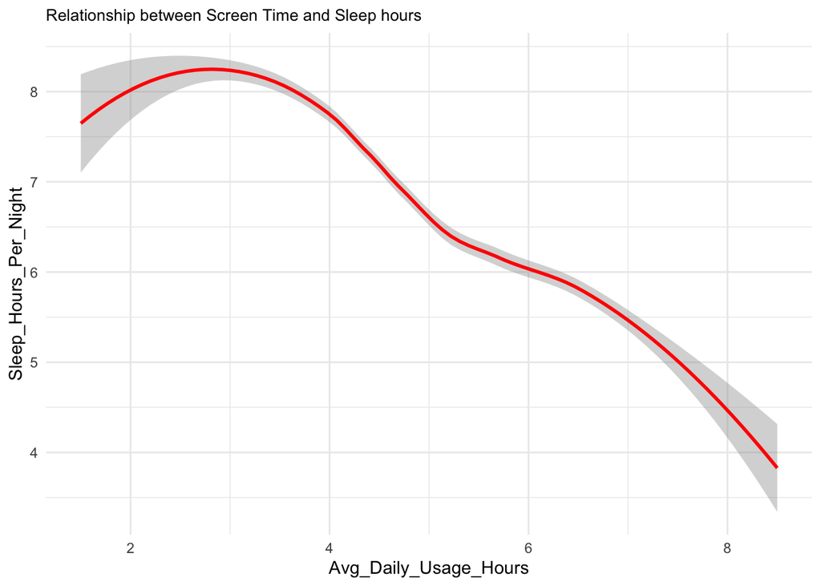

```r
ggplot(tidy_data,
       aes(x= Avg_Daily_Usage_Hours, y= Sleep_Hours_Per_Night))+
  geom_smooth(model= "lm", se= TRUE, color = "red")+
  labs(title = "Relationship between Screen Time and Sleep hours")+
  theme_minimal()+
  theme(plot.title = element_text(size =10))
```

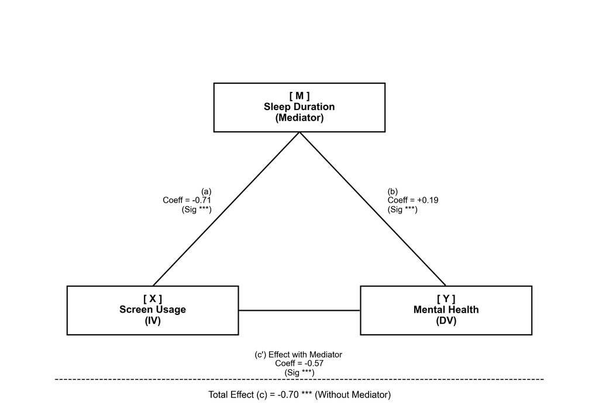

Based on the result, H1 was supported. For better understand the relationship, we draw a path analysis figure. From this figure we can see that overall, longer screen-time usage significantly harms mental health (coeff = −0.70). This also supports our hypothesis that sleep duration partially mediates this relationship: excessive screen time reduces sleep, which in turn contributes to poorer mental health. However, this is not the whole story. Even after accounting for sleep and ensuring adequate sleep duration, screen overuse still shows a significant direct negative effect on mental health (direct coeff= −0.57), suggesting that excessive screen use may harm mental health through additional mechanisms beyond sleep.

*RQ*<sub>2</sub>:Is there a critical ‘tipping point’ in screen usage where sleep duration and mental health exhibit a sharp decline?

- *H*<sub>2</sub>: Students exceeding a threshold of 5 hours per day will report significantly worse outcomes compared to low-usage groups, whereas the difference between low (0~3) and moderate usage (3~5)may be minimal. (In my own experience, I use screens for 3–5 hours per day and do not perceive any notable mental-health issues)
- *H*<sub>3</sub>: However, this pattern may vary by gender, and the differences in outcomes may not be the same across male and female students.

```r
group_data <- tidy_data |>
  mutate(Usage_Group = cut(
      Avg_Daily_Usage_Hours,
      breaks = c(0, 3, 5, Inf),
      labels = c("Low (0–3h)", "Moderate (3–5h)", "High (>5h)"))
      )

male_data <- group_data |>
  filter(Gender == "Male") |>
  select(Gender, Avg_Daily_Usage_Hours, Sleep_Hours_Per_Night,Mental_Health_Score,Usage_Group)


female_data <- group_data |>
  filter(Gender == "Female") |>
  select(Gender, Avg_Daily_Usage_Hours, Sleep_Hours_Per_Night,Mental_Health_Score,Usage_Group)
```

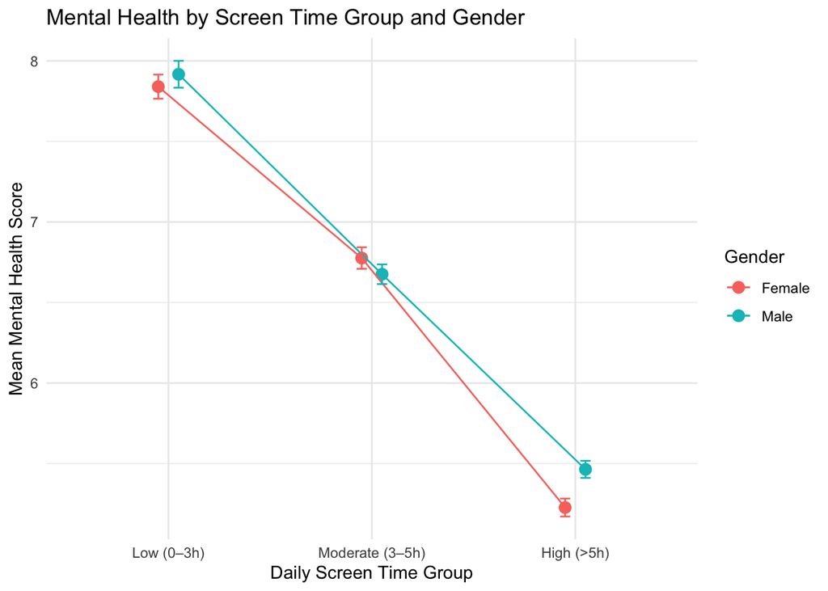

```r
summary_data <- group_data |>
  group_by(Gender, Usage_Group) |>
  summarise(
    mean_MH = mean(Mental_Health_Score),
    sd_MH   = sd(Mental_Health_Score),
    n       = n(),
    se_MH   = sd_MH / sqrt(n)
  ) |>
  ungroup()

ggplot(summary_data,
       aes(x = Usage_Group,
           y = mean_MH,
           group = Gender,
           color = Gender)) +
  geom_point(position = position_dodge(width = 0.2), size = 3) +
  geom_line(position = position_dodge(width = 0.2)) +
  geom_errorbar(
    aes(ymin = mean_MH - se_MH,
        ymax = mean_MH + se_MH),
    width = 0.1,
    position = position_dodge(width = 0.2)
  ) +
  labs(
    x = "Daily Screen Time Group",
    y = "Mean Mental Health Score",
    color = "Gender",
    title = "Mental Health by Screen Time Group and Gender"
  ) +
  theme_minimal()
```

It does show a negative effect of daily screen time on mental health, but there is no clear “tipping point.” Instead, the decline appears more stepwise, with mental health decreasing gradually across each usage group.

The most interesting finding is that the downward trend is evident for both genders, but the decline is notably steeper among female students, especially in the high-usage category, suggesting that excessive screen exposure may have a stronger negative impact on females’ psychological well-being.

To statistically verify the patterns observed in the plot, we conducted separate one-way ANOVAs for male and female students

```r
#one-way ANOVAs
anova_male <- aov(Mental_Health_Score ~ Usage_Group, data = male_data)
TukeyHSD(anova_male)
```

```
  Tukey multiple comparisons of means
    95% family-wise confidence level

Fit: aov(formula = Mental_Health_Score ~ Usage_Group, data = male_data)

$Usage_Group
                                diff      lwr        upr p adj
Moderate (3–5h)-Low (0–3h) -1.241135 -1.61745 -0.8648198     0
High (>5h)-Low (0–3h)      -2.452381 -2.83593 -2.0688323     0
High (>5h)-Moderate (3–5h) -1.211246 -1.40505 -1.0174425     0
```

```r
anova_female <- aov(Mental_Health_Score ~ Usage_Group, data = female_data)
TukeyHSD(anova_female)
```

```
  Tukey multiple comparisons of means
    95% family-wise confidence level

Fit: aov(formula = Mental_Health_Score ~ Usage_Group, data = female_data)

$Usage_Group
                                diff       lwr        upr p adj
Moderate (3–5h)-Low (0–3h) -1.064138 -1.454708 -0.6735675     0
High (>5h)-Low (0–3h)      -2.612727 -3.006471 -2.2189836     0
High (>5h)-Moderate (3–5h) -1.548589 -1.750621 -1.3465577     0
```

The post hoc Tukey tests confirmed significant differences across all usage groups in both genders, with female students showing larger mean declines, particularly between the moderate and high usage levels.

## RQ3-RQ5, H4

*RQ*<sub>3</sub>: How does primary usage of a specific social media platform impact mental health?

*H*<sub>4</sub>: Meta-affiliated platforms, such as Facebook and Instagram, will result in a greater impact to mental health compared to other platforms.

```r
platform_mental_health <- platform_use |>
  group_by(Most_Used_Platform) |>
  summarize(
    n = n(),
    mean_pmh = mean(Mental_Health_Score, na.rm = TRUE),
    sd_pmh = sd(Mental_Health_Score, na.rm = TRUE)
  ) |>
  arrange(mean_pmh) |>
  rename(
    `Most Used Platform` = Most_Used_Platform,
    Mean = mean_pmh,
    `Standard Deviation` = sd_pmh
  )

platform_mental_health |>
  kable(
    caption = "Mean Mental Health Scores by Platform",
    digits = 2
  )
```

Mean Mental Health Scores by Platform

| Most Used Platform | n | Mean | Standard Deviation |
| --- | --- | --- | --- |
| WhatsApp | 54 | 5.54 | 0.50 |
| Snapchat | 13 | 5.54 | 0.78 |
| TikTok | 154 | 5.71 | 0.80 |
| KakaoTalk | 12 | 6.00 | 0.00 |
| Instagram | 249 | 6.12 | 1.17 |
| WeChat | 15 | 6.47 | 0.52 |
| YouTube | 10 | 6.60 | 0.70 |
| Facebook | 123 | 6.72 | 1.03 |
| Twitter | 30 | 6.83 | 1.05 |
| VKontakte | 12 | 7.00 | 0.00 |
| LINE | 12 | 8.00 | 0.00 |
| LinkedIn | 21 | 8.00 | 0.32 |

Based on the results in this table, we cannot definitively correlate the use of Meta-owned platforms to lower self-reported mental health scores. *H*<sub>4</sub> is not supported.

*RQ*<sub>4</sub>: Do any specific social media platforms significantly correlate to lower self-reported mental health statuses?

```r
pu_mean_mh <- mean(platform_use$Mental_Health_Score, na.rm = TRUE)

platform_use <- platform_use |>
  mutate(
    low_mh = if_else(Mental_Health_Score < pu_mean_mh, "Low", "Not Low"),
    low_mh = factor(low_mh, levels = c("Low", "Not Low"))
  )

mh_count <- platform_use |>
  group_by(Most_Used_Platform, low_mh) |>
  summarize(
    n = n(),
    .groups = "drop"
  )

mh_wide <- mh_count |>
  pivot_wider(
    names_from = low_mh,
    values_from = n,
    values_fill = 0
  )

mh_wide <- mh_wide |>
  mutate(
    total = Low + `Not Low`,
    pct_low = Low / total * 100,
    pct_not_low = `Not Low` / total * 100
  ) |>
  mutate(
    pct_low = round(pct_low, 1),
    pct_not_low = round(pct_not_low, 1)
  ) |>
  rename(
    `Most Used Platform` = Most_Used_Platform,
    Total = total,
    `Low (%)` = pct_low,
    `Not Low (%)` = pct_not_low
  )

mh_wide |>
  select(-Low, -`Not Low`, -Total) |>
  kable(
    caption = "Percentages of Lower Than Average Mental Health Reports by Platform",
    digits = 3
  )
```

Percentages of Lower Than Average Mental Health Reports by Platform

| Most Used Platform | Low (%) | Not Low (%) |
| --- | --- | --- |
| Facebook | 27.6 | 72.4 |
| Instagram | 61.8 | 38.2 |
| KakaoTalk | 100.0 | 0.0 |
| LINE | 0.0 | 100.0 |
| LinkedIn | 0.0 | 100.0 |
| Snapchat | 92.3 | 7.7 |
| TikTok | 86.4 | 13.6 |
| Twitter | 36.7 | 63.3 |
| VKontakte | 0.0 | 100.0 |
| WeChat | 53.3 | 46.7 |
| WhatsApp | 100.0 | 0.0 |
| YouTube | 30.0 | 70.0 |

An initial glance at this data suggested that the majority of those who primarily use Instagram, KakaoTalk, Snapchat, TikTok, WeChat, and WhatsApp have lower-than-average reported mental health. Using a chi-square test of independence, we sought to measure if these differences reflect a statistically significant relationship instead of chance.

```r
mh_chi <- mh_wide |>
  select(Low, `Not Low`) |>
  as.matrix()

rownames(mh_chi) <- mh_wide$Most_Used_Platform

mh_chi <- chisq.test(mh_chi)

mh_chi
```

```
    Pearson's Chi-squared test

data:  mh_chi
X-squared = 226.05, df = 11, p-value < 2.2e-16
```

These results indicated a significant association between primary platform use and reported mental health status (χ² = 226.05, *df* = 11, *p* < .001), suggesting that low versus not-low mental health frequencies vary across platforms to a noteworthy degree.

*RQ*<sub>5</sub>: Do any specific platforms correlate to higher levels of social media addiction?

```r
platform_addiction <- platform_use |>
  group_by(Most_Used_Platform) |>
  summarize(
    n = n(),
    mean_addiction = mean(Addicted_Score, na.rm = TRUE),
    sd_addiction = sd(Addicted_Score, na.rm = TRUE)
  ) |>
  rename(
    `Most Used Platform` = Most_Used_Platform,
    `Mean` = mean_addiction,
    `Standard Deviation` = sd_addiction
  ) |>
  arrange(desc(`Mean`))

platform_addiction |>
  kable(
    caption = "Social Media Addiction by Platform",
    digits = 2
  )
```

Social Media Addiction by Platform

| Most Used Platform | n | Mean | Standard Deviation |
| --- | --- | --- | --- |
| WhatsApp | 54 | 7.46 | 0.50 |
| Snapchat | 13 | 7.46 | 0.78 |
| TikTok | 154 | 7.43 | 1.04 |
| Instagram | 249 | 6.55 | 1.54 |
| YouTube | 10 | 6.10 | 1.37 |
| WeChat | 15 | 6.07 | 1.03 |
| KakaoTalk | 12 | 6.00 | 0.00 |
| Facebook | 123 | 5.67 | 1.44 |
| Twitter | 30 | 5.50 | 1.55 |
| VKontakte | 12 | 5.00 | 0.00 |
| LinkedIn | 21 | 3.81 | 0.60 |
| LINE | 12 | 3.00 | 0.00 |

The resulting data indicated that those who reported using WhatsApp or Snapchat the most also reported the highest level of addiction to social media (*M<sub>WA</sub>* = 7.46, *SD* = 0.50; *M<sub>S</sub>* = 7.46, *SD* = 0.78), closely followed by those who reported TikTok as their most used platform (*M* = 7.43, *SD* = 1.04). Those who reported using LINE as their most used platform reported the lowest level of addiction to social media (*M* = 3.00, *SD* = 0.00).

## RQ6

*RQ*<sub>6</sub>: Among college students, comparing students from the US to those from the Middle East and the Far East, how does mental health affect conflicts over social media?

For this question, we are filtering the responses into three groups by country: the USA, the Middle Easterns, and the Far Easterns. We are also exclusively looking at college students, both undergrad and grad, thereby removing high schoolers.

```r
sm <- import(here("data", "tidy_data.csv")) |>
  clean_names()

middle_east <- c("Bahrain", "Iraq", "Israel", "Jordan", "Kuwait",
                 "Lebanon", "Oman", "Qatar", "Syria", "Turkey",
                 "UAE", "Yemen")

far_east <- c("China", "Japan", "South Korea", "Taiwan", "Singapore",
              "Malaysia", "Indonesia", "Vietnam", "Philippines",
              "Thailand", "Hong Kong")

# Use the right column and classifications to filter for college students.
# Create a new column for our three regions.
students <- sm |>
  filter(academic_level %in% c("Undergraduate", "Graduate")) |>
  mutate(
    region = case_when(
      country == "USA" ~ "USA",
      country %in% middle_east ~ "Middle East",
      country %in% far_east ~ "Far East",
      TRUE ~ NA_character_
    )
  ) |>
  filter(!is.na(region)) |> # Select the columns to use.
  select(student_id,
         region,
         academic_level,
         age,
         gender,
         mental_health_score,
         conflicts_over_social_media)

skim(students) # For a quick check.
```

Data summary

| Name | students |
| --- | --- |
| Number of rows | 150 |
| Number of columns | 7 |
| _______________________ |  |
| Column type frequency: |  |
| character | 3 |
| numeric | 4 |
| ________________________ |  |
| Group variables | None |

**Variable type: character**

| skim_variable | n_missing | complete_rate | min | max | empty | n_unique | whitespace |
| --- | --- | --- | --- | --- | --- | --- | --- |
| region | 0 | 1 | 3 | 11 | 0 | 3 | 0 |
| academic_level | 0 | 1 | 8 | 13 | 0 | 2 | 0 |
| gender | 0 | 1 | 4 | 6 | 0 | 2 | 0 |

**Variable type: numeric**

| skim_variable | n_missing | complete_rate | mean | sd | p0 | p25 | p50 | p75 | p100 | hist |
| --- | --- | --- | --- | --- | --- | --- | --- | --- | --- | --- |
| student_id | 0 | 1 | 407.60 | 187.58 | 3 | 275.5 | 426.5 | 555.75 | 704 | ▃▅▆▇▇ |
| age | 0 | 1 | 20.48 | 1.44 | 19 | 19.0 | 20.0 | 21.00 | 24 | ▇▂▂▁▁ |
| mental_health_score | 0 | 1 | 5.98 | 1.13 | 4 | 5.0 | 6.0 | 6.00 | 8 | ▂▅▇▁▃ |
| conflicts_over_social_media | 0 | 1 | 2.97 | 0.99 | 0 | 3.0 | 3.0 | 4.00 | 4 | ▁▂▂▇▆ |

Now we can run inferential tests with mental health as the IV, region as the grouping, and conflicts over social media as the DV.

```r
# Center mental health.
students <- students |>
  mutate(mh_c = scale(mental_health_score, center = TRUE, scale = FALSE))

# Interaction model for differences by region.
model_int <- lm(conflicts_over_social_media ~ mh_c * region, data = students)
summary(model_int)
```

```
Call:
lm(formula = conflicts_over_social_media ~ mh_c * region, data = students)

Residuals:
     Min       1Q   Median       3Q      Max
-1.25103 -0.10608  0.03888  0.04121  0.74897

Coefficients:
                        Estimate Std. Error t value Pr(>|t|)
(Intercept)             2.978223   0.047645  62.509  < 2e-16 ***
mh_c                   -0.855046   0.039746 -21.513  < 2e-16 ***
regionMiddle East       0.001711   0.068796   0.025 0.980188
regionUSA               0.336879   0.098920   3.406 0.000856 ***
mh_c:regionMiddle East -0.202437   0.074392  -2.721 0.007306 **
mh_c:regionUSA          0.406067   0.078210   5.192 6.96e-07 ***
---
Signif. codes:  0 '***' 0.001 '**' 0.01 '*' 0.05 '.' 0.1 ' ' 1

Residual standard error: 0.2982 on 144 degrees of freedom
Multiple R-squared:  0.9116,    Adjusted R-squared:  0.9085
F-statistic: 296.9 on 5 and 144 DF,  p-value: < 2.2e-16
```

```r
anova(model_int)
```

```
Analysis of Variance Table

Response: conflicts_over_social_media
             Df  Sum Sq Mean Sq   F value    Pr(>F)
mh_c          1 127.617 127.617 1435.1067 < 2.2e-16 ***
region        2   0.376   0.188    2.1116    0.1248
mh_c:region   2   4.035   2.018   22.6902 2.716e-09 ***
Residuals   144  12.805   0.089
---
Signif. codes:  0 '***' 0.001 '**' 0.01 '*' 0.05 '.' 0.1 ' ' 1
```

```r
# Correlation by region.
cor_by_region <- students |>
  group_by(region) |>
  summarise(
    n = n(),
    r_mh_conflict = cor(mental_health_score,
                        conflicts_over_social_media,
                        use = "pairwise.complete.obs")
  )

kable(cor_by_region, digits = 3,
      caption = "Correlation Between Mental Health and Social Media Conflicts by Region")
```

Correlation Between Mental Health and Social Media Conflicts by Region

| region | n | r_mh_conflict |
| --- | --- | --- |
| Far East | 69 | -0.902 |
| Middle East | 41 | -0.983 |
| USA | 40 | -0.786 |

```r
# Few basic descriptive statistics.
desc_table <- students |>
  group_by(region) |>
  summarise(
    n = n(),
    mean_mh = mean(mental_health_score, na.rm = TRUE),
    sd_mh   = sd(mental_health_score, na.rm = TRUE),
    mean_conflict = mean(conflicts_over_social_media, na.rm = TRUE),
    sd_conflict   = sd(conflicts_over_social_media, na.rm = TRUE)
  )
```

With a multiple regression model that included centered mental health scores, three regions, and their interaction, the descriptive statistics show that students from the Far East reported the highest mental health scores (M = 6.77, SD = 0.91) and the lowest social media conflict levels (M = 2.30, SD = 0.86), followed by students from the Middle East next (M = 5.71, SD = 0.75; M = 3.27, SD = 0.81, respectively) and the United States last (M = 4.90, SD = 0.71; M = 3.80, SD = 0.41). Mental health was strongly and negatively associated with social media conflict across the board, and the relationship varied by the region, with the strongest correlations observed in the Middle East (r = −.98), followed by the Far East (r = −.90) and the United States (r = −.79). It was also revealed that the strength of this association was significantly different across regions, which suggest that poorer mental health predicts higher levels of confict over social media more strongly in the Middle East and the Far East in comparison to students in the US.

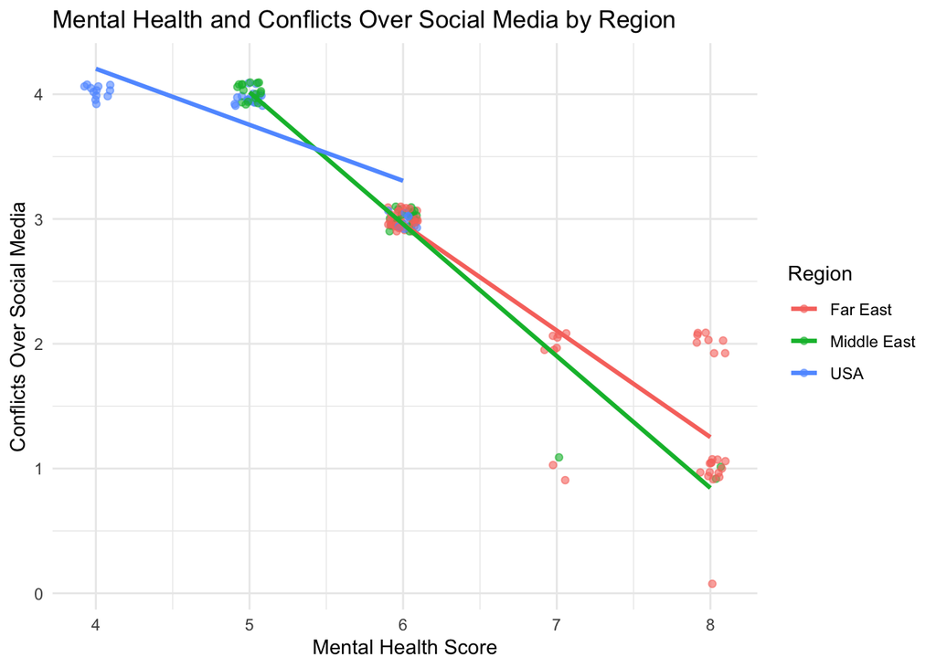

```r
ggplot(students,
       aes(x = mental_health_score,
           y = conflicts_over_social_media,
           color = region)) +
  geom_jitter(width = 0.1, height = 0.1, alpha = 0.6) +
  geom_smooth(method = "lm", se = FALSE, size = 1.1) +
  labs(
    title = "Mental Health and Conflicts Over Social Media by Region",
    x = "Mental Health Score",
    y = "Conflicts Over Social Media",
    color = "Region"
  ) +
  theme_minimal()
```

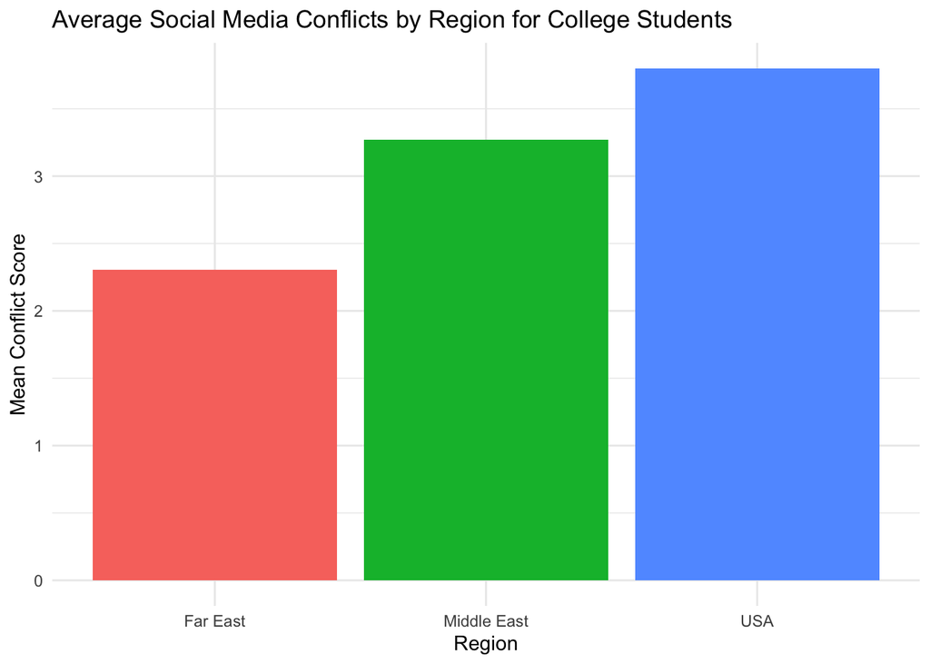

```r
students |>
  group_by(region) |>
  summarise(mean_conflict = mean(conflicts_over_social_media, na.rm = TRUE)) %>%
  ggplot(aes(x = region, y = mean_conflict, fill = region)) +
  geom_col() +
  labs(
    title = "Average Social Media Conflicts by Region for College Students",
    x = "Region",
    y = "Mean Conflict Score"
  ) +
  theme_minimal() +
  theme(legend.position = "none")
```